# Robust PCA data filtering

Scott Campit

# 1. Load libraries

```r
library(FactoMineR)
```

# 2. Read in data

```r
rm(list=ls())

# Dell
datapath = 'D:/Data/CRISPR/Achilles/Achilles_gene_effect.csv'

# Linux
#datapath = '~/Data/CRISPR/Achilles_gene_effect.csv'

# Read in data
data = readr::read_csv(datapath)
```

## Grab CCLE meta data

First, we’ll get relevant meta data

```r
# Linux
#metapath = "~/Data/CRISPR/sample_info.csv"

# Dell
metapath = 'D:/Data/Mappings/CCLE/sample_info.csv'

# Read in meta data
meta_data = read_csv(metapath)
meta_data = meta_data[, c("DepMap_ID",
                        "stripped_cell_line_name",
                        "primary_or_metastasis",
                        "lineage",
                        "lineage_subtype")]
```

# 3. Dimension reduction with CERES Scores

First, we’ll grab the CERES Scores.

```r
ceres = data[, 2:ncol(data)]
ceres = data.matrix(ceres)
ceres[is.na(ceres)] = 0
ceres = as.matrix(ceres)
ids = data.frame(data[, 1])
```

First, we’ll create a function that can perform ROBPCA on the data.

```r
# Create a function that filters data using ROBPCA
removeOutliers = function(data, id){
  pca_obj = PcaHubert(data)
  filtered_data = data[pca_obj@flag, ]
  filtered_id = id[pca_obj@flag,]
  outlier_data = data[!pca_obj@flag, ]
  outlier_id = id[!pca_obj@flag,]

  setClass(Class="geneObj",
           representation(
             data="matrix",
             outlier_data="matrix",
             id="character",
             flag="logical",
             outlier_id="character",
             robpca='PcaHubert'
           )
   )
   return(new("geneObj",
          data=filtered_data,
          outlier_data=outlier_data,
          id=filtered_id,
          flag=pca_obj@flag,
          outlier_id=outlier_id,
          robpca=pca_obj))
}
```

## Perform PCA

```r
pca_obj = prcomp(ceres, scale=FALSE)
```

## Visualize PCA Scores Plot

Let’s visualize the original PCA dimension reduction.

```r
scores = data.frame(pca_obj[["x"]])
ggplot(scores, aes(x=PC1, y=PC2)) +
  geom_point() +
  labs(title="CERES Scores Plot",
       x="PC1",
       y="PC2") +
  theme(legend.position="none")
```

## Visualize cell line distribution

Let’s also get the distribution of the data

```r
outlier_id = data.frame(ids)
filtered_cell_lines = merge(meta_data,
                            outlier_id,
                            by.x='DepMap_ID',
                            by.y='DepMap_ID')
```

Now let’s plot it

```r
# Group by
tmp = aggregate(filtered_cell_lines$lineage,
                by=list(filtered_cell_lines$lineage),
                length)
tmp = tmp %>% arrange(x)
tmp$Group.1 = factor(tmp$Group.1,
                     levels=tmp$Group.1[order(tmp$x, decreasing = TRUE)])

# Plot by tissue
ggplot(data=tmp,
       aes(x=Group.1,
           y=x,
           fill=x,
           label=x)) +
  geom_bar(stat='identity',
           position='dodge') +
  coord_flip() +
  labs(y="Number of cell lines per tissue",
       x="Tissue lineage",
       title="All intersecting cell lines") +
  guides(fill=guide_legend(title="N cell lines")) +
  geom_text(aes(label=x),
            position=position_dodge(width=0.9))
```

## Robust PCA

Now let’s remove some outliers using Robust PCA:

```r
robpca_ceres = removeOutliers(ceres, ids)

rob_scores = data.frame(robpca_ceres@robpca$scores)
ggplot(rob_scores, aes(x=PC1, y=PC2)) +
  geom_point() +
  labs(title="CERES Robust PCA Scores Plot",
       x="PC1",
       y="PC2") +
  theme(legend.position="none")
```

## Visualize cell lines that are omitted from ROBPCA

I am curious about what cell lines are omitted.

```r
outlier_id = data.frame(robpca_ceres@outlier_id)
filtered_cell_lines = merge(meta_data,
                            outlier_id,
                            by.x='DepMap_ID',
                            by.y='robpca_ceres.outlier_id')
```

## Visualize outlier cell line distribution

Visualize the cell lines that are omitted from downstream analyses.

```r
# Group by
tmp = aggregate(filtered_cell_lines$lineage,
                by=list(filtered_cell_lines$lineage),
                length)
tmp = tmp %>% arrange(x)
tmp$Group.1 = factor(tmp$Group.1,
                     levels=tmp$Group.1[order(tmp$x, decreasing = TRUE)])

# Plot by tissue
ggplot(data=tmp,
       aes(x=Group.1,
           y=x,
           fill=x,
           label=x)) +
  geom_bar(stat='identity',
           position='dodge') +
  coord_flip() +
  labs(y="Number of cell lines removed",
       x="Tissue lineage",
       title="Cell lines removed from robust PCA") +
  guides(fill=guide_legend(title="N cell lines")) +
  geom_text(aes(label=x),
            position=position_dodge(width=0.9),
            hjust=-0.25)
```

## Repeat ROBPCA filter for genes

```r
tmp = robpca_ceres@data
tmpid = robpca_ceres@id
rownames(tmp) = tmpid
tmp = t(tmp)
tmpid = data.frame(rownames(tmp))
robpca_ceres = removeOutliers(tmp, tmpid)
```

## Construction final dataset for downstream analysis

We’ll use the ceres data from the Robust PCA analysis.

```r
ceres = t(robpca_ceres@data)
ids = rownames(ceres)
rm(list=c("pca_obj", "robpca_ceres", "robscores", "scores"))
save(list=c("ceres", "ids"), file=savepath)
load(savepath)
```

# 4. Dimension reduction with Project DRIVE

```r
ids = row.names(merged_df)
data = as.matrix(merged_df)
```

First, we’ll create a function that can perform ROBPCA on the data.

```r
# Create a function that filters data using ROBPCA
removeOutliers = function(data, id){
  pca_obj = PcaHubert(data)
  filtered_data = data[pca_obj@flag, ]
  filtered_id = id[pca_obj@flag,]
  outlier_data = data[!pca_obj@flag, ]
  outlier_id = id[!pca_obj@flag,]

  setClass(Class="geneObj",
           representation(
             data="matrix",
             outlier_data="matrix",
             id="character",
             flag="logical",
             outlier_id="character",
             robpca='PcaHubert'
           )
   )
   return(new("geneObj",
          data=filtered_data,
          outlier_data=outlier_data,
          id=filtered_id,
          flag=pca_obj@flag,
          outlier_id=outlier_id,
          robpca=pca_obj))
}
```

## Perform PCA

Run PCA

```r
pca_obj = prcomp(data, scale=FALSE)
```

Run PCA

```r
scores = PCA(data, graph = FALSE)
res = HCPC(scores, graph=FALSE)
```

## Scree plot

Get scree plot

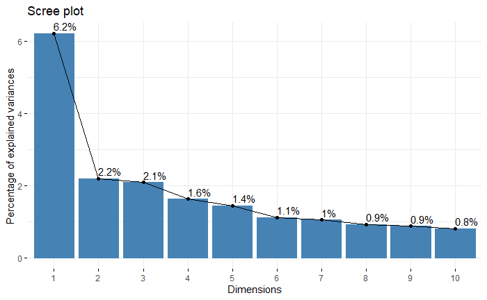

Get variable contribution

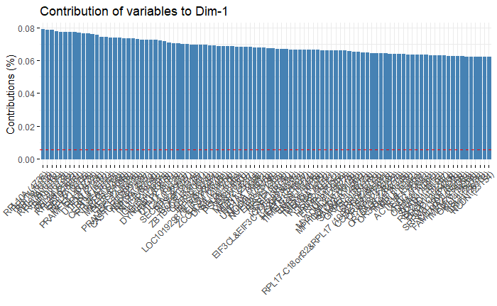

```r
# Dendrogram
#fviz(res,
#     cex=0.7,                     # Label size
#     palette="jco",               # Color palette see ?ggpubr::ggpar
#     rect=TRUE, rect_fill=TRUE, # Add rectangle around groups
#     rect_border="jco",           # Rectangle color
#     labels_track_height=0.8      # Augment the room for labels
#    )
```

## Scores plot with K-means cluster

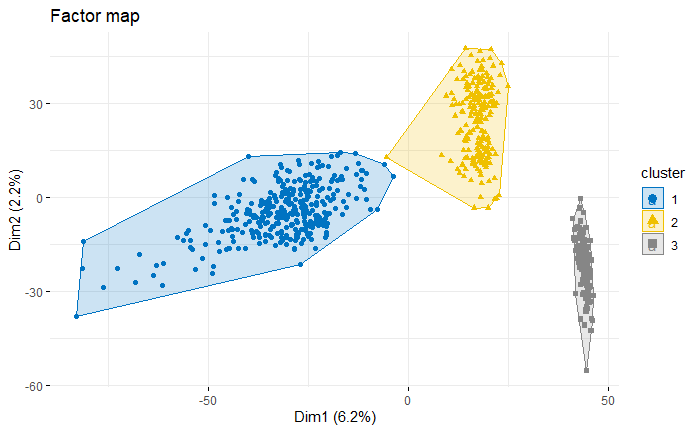

```r
# Factor map
fviz_cluster(res,
             repel=TRUE,            # Avoid label overlapping
             show.clust.cent=TRUE, # Show cluster centers
             palette="jco",         # Color palette see ?ggpubr::ggpar
             ggtheme=theme_minimal(),
             main="Factor map"
             )
```

## Visualize PCA Scores Plot

Let’s visualize the original PCA dimension reduction.

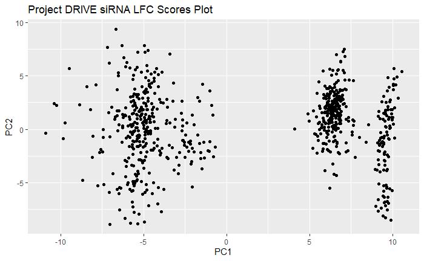

## Visualize cell line distribution

Let’s also get the distribution of the data

```r
outlier_id = data.frame(ids)
filtered_cell_lines = merge(meta_data,
                            outlier_id,
                            by.x='DepMap_ID',
                            by.y='DepMap_ID')
```

Now let’s plot it

```r
# Group by
tmp = aggregate(filtered_cell_lines$lineage,
                by=list(filtered_cell_lines$lineage),
                length)
tmp = tmp %>% arrange(x)
tmp$Group.1 = factor(tmp$Group.1,
                     levels=tmp$Group.1[order(tmp$x, decreasing = TRUE)])

# Plot by tissue
ggplot(data=tmp,
       aes(x=Group.1,
           y=x,
           fill=x,
           label=x)) +
  geom_bar(stat='identity',
           position='dodge') +
  coord_flip() +
  labs(y="Number of cell lines per tissue",
       x="Tissue lineage",
       title="All intersecting cell lines") +
  guides(fill=guide_legend(title="N cell lines")) +
  geom_text(aes(label=x),
            position=position_dodge(width=0.9))
```

## Robust PCA

Now let’s remove some outliers using Robust PCA:

```r
robpca_ceres = removeOutliers(ceres, ids)

rob_scores = data.frame(robpca_ceres@robpca$scores)
ggplot(rob_scores, aes(x=PC1, y=PC2)) +
  geom_point() +
  labs(title="CERES Robust PCA Scores Plot",
       x="PC1",
       y="PC2") +
  theme(legend.position="none")
```

## Visualize cell lines that are omitted from ROBPCA

I am curious about what cell lines are omitted.

```r
outlier_id = data.frame(robpca_ceres@outlier_id)
filtered_cell_lines = merge(meta_data,
                            outlier_id,
                            by.x='DepMap_ID',
                            by.y='robpca_ceres.outlier_id')
```

## Visualize outlier cell line distribution

Visualize the cell lines that are omitted from downstream analyses.

```r
# Group by
tmp = aggregate(filtered_cell_lines$lineage,
                by=list(filtered_cell_lines$lineage),
                length)
tmp = tmp %>% arrange(x)
tmp$Group.1 = factor(tmp$Group.1,
                     levels=tmp$Group.1[order(tmp$x, decreasing = TRUE)])

# Plot by tissue
ggplot(data=tmp,
       aes(x=Group.1,
           y=x,
           fill=x,
           label=x)) +
  geom_bar(stat='identity',
           position='dodge') +
  coord_flip() +
  labs(y="Number of cell lines removed",
       x="Tissue lineage",
       title="Cell lines removed from robust PCA") +
  guides(fill=guide_legend(title="N cell lines")) +
  geom_text(aes(label=x),
            position=position_dodge(width=0.9),
            hjust=-0.25)
```

## Repeat ROBPCA filter for genes

```r
tmp = robpca_drive@data
tmpid = robpca_drive@id
rownames(tmp) = tmpid
tmp = t(tmp)
tmpid = data.frame(rownames(tmp))
robpca_drive = removeOutliers(tmp, tmpid)
```